# engellant_VO2_max_tests

Andrew Engellant

2024-03-01

A VO2 max test, or maximal oxygen uptake test, is a measure of the maximum amount of oxygen that an individual can utilize during intense exercise. It is considered a gold standard for evaluating an individual’s aerobic fitness and cardiovascular endurance. The test involves progressively increasing the intensity of exercise (typically running on a treadmill) while measuring oxygen consumption and heart rate. The maximum volume of oxygen consumed (VO2 max) is measured in milliliters of oxygen consumed per kg of body weight per minute. The higher your VO2 max, the more aerobically fit you are considered to be.

Descriptions of the variables in this dataset are below. Each observation describes several aspects of the individual participating in the VO2 max test, and their respective score.

**training** - the average intensity of training an individual does on a weekly basis. This category is ranked from ‘intense’ (an individual who does intense aerobic activity daily) to ‘none’ (an individual who does no aerobic activity).

**assigned_sex** - the sex of the individual, either male or female.

**height** - the height of the individual measured in inches.

**weight** - the nude body weight of the individual measured in pounds.

**age** - the age of the individual measured in years.

**max_hr** - the individuals maximum heart rate measured during the VO2 max test.

**VO2_Max** - the individuals score from the VO2 Max test.

A few descriptive statistics are displayed below.

```r
library(ggplot2)

d <- read.table("engellant_VO2.txt",
                header = TRUE)
# Summary of continuous variables
summary(d[,4:8])
```

```
##      height          weight           max_hr           age
##  Min.   :52.42   Min.   : 50.27   Min.   :176.3   Min.   : 9.817
##  1st Qu.:64.62   1st Qu.:142.06   1st Qu.:188.6   1st Qu.:28.287
##  Median :67.86   Median :164.34   Median :192.0   Median :32.644
##  Mean   :68.02   Mean   :164.71   Mean   :191.9   Mean   :32.620
##  3rd Qu.:71.41   3rd Qu.:187.53   3rd Qu.:195.1   3rd Qu.:36.985
##  Max.   :84.04   Max.   :276.20   Max.   :207.7   Max.   :59.183
##     VO2_Max
##  Min.   :15.25
##  1st Qu.:34.13
##  Median :40.23
##  Mean   :41.02
##  3rd Qu.:47.46
##  Max.   :75.02
```

```r
# Correlation for continuous variables
cor(d[,4:8])
```

```
##              height       weight       max_hr         age      VO2_Max
## height  1.000000000  0.011125743  0.002007979  0.03961540  0.004261857
## weight  0.011125743  1.000000000 -0.009756758  0.02423271 -0.212988834
## max_hr  0.002007979 -0.009756758  1.000000000 -0.01423255  0.046118221
## age     0.039615397  0.024232712 -0.014232550  1.00000000 -0.075728540
## VO2_Max 0.004261857 -0.212988834  0.046118221 -0.07572854  1.000000000
```

```r
table(d$training, d$assigned_sex)
```

```
##
##            female male
##   high         77  127
##   intense      31   53
##   low          93  156
##   moderate    117  186
##   none         62   98
```

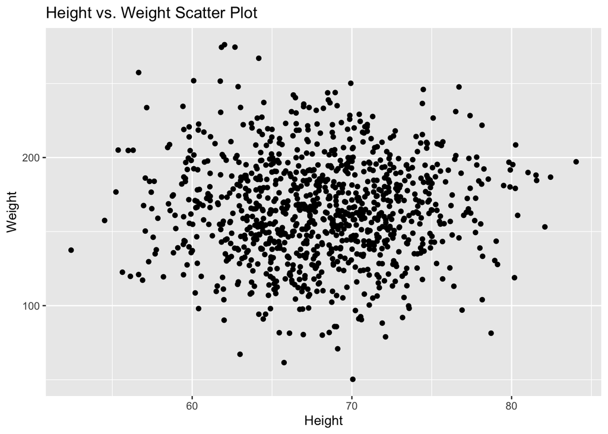

```r
# Create a scatter plot
ggplot(d, aes(x = height, y = weight)) +
  geom_point() +
  labs(x = "Height", y = "Weight", title = "Height vs. Weight Scatter Plot")
```

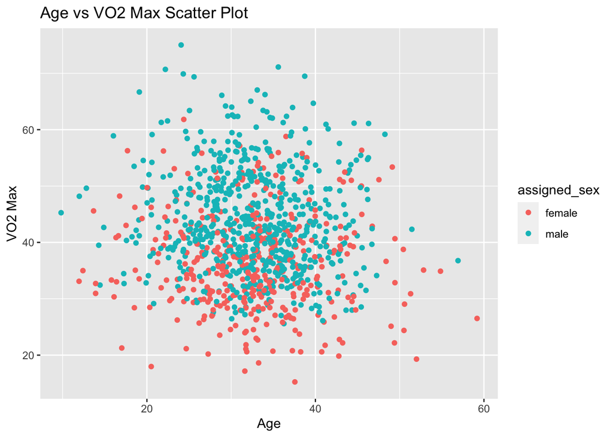

```r
ggplot(d, aes(x = age, y = VO2_Max, col = assigned_sex)) +
  geom_point() +
  labs(x = "Age", y = "VO2 Max", title = "Age vs VO2 Max Scatter Plot")
```

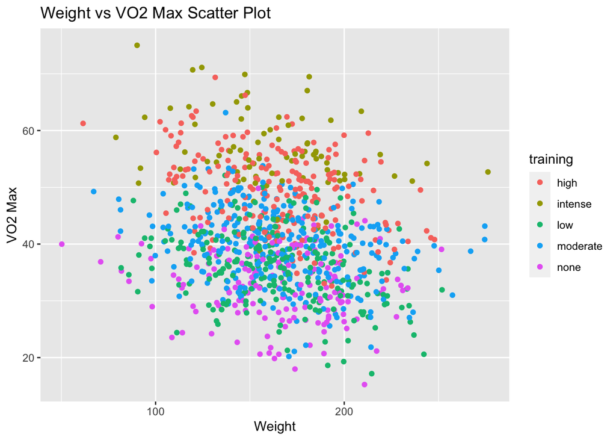

```r
ggplot(d, aes(x = weight, y = VO2_Max, col = training)) +
  geom_point() +
  labs(x = "Weight", y = "VO2 Max", title = "Weight vs VO2 Max Scatter Plot")
```